# Project Two: Biomechanical Features of Orthopedic Patients

chris mathew

27 March 2021

# Introduction

This report is my second submission for the capstone project for *HarvardX PH125.9x*. For this project we chose our own dataset and objectives. I use a curated dataset from *Kaggle*, which is used to predict medical conditions. My obective is to build a ensemble-based predictor and investigate if this predictor performs better than the individual constituent models.

I was motivated to do this becuase I wanted to do something that was related to medecine.

## Description of the dataset

The data is sourced from one of Kaggle’s curated datasets: [Biomechanical features of orthopedic patients](https://www.kaggle.com/uciml/biomechanical-features-of-orthopedic-patients?select=column_3C_weka.csv).

and for convenince it has been re-uploaded to my [personal github](https://raw.github.com/gisforgringo/harvard/master/column_3C_weka.csv).

The dataset is used for predicting various medical conditions. There are 310 obsersavations of 6 numeric features. The features are:

- pelvic_incidence
- pelvic_tilt
- lumbar_lordosis_angle
- sacral_slope
- pelvic_radius
- degree_spondylolisthesis

These are used to to predict a patient’s condition as Hernia, Spondylolisthesis or Normal. These have the following frequencies:

Counts of Class

| class | n() |
| --- | --- |
| Hernia | 60 |
| Normal | 100 |
| Spondylolisthesis | 150 |

A sample of the dataset and histograms of the features are shown below:

Sample of dataset

| pelvic_incidence | pelvic_tilt | lumbar_lordosis_angle | sacral_slope | pelvic_radius | degree_spondylolisthesis | class |
| --- | --- | --- | --- | --- | --- | --- |
| 63.02782 | 22.552586 | 39.60912 | 40.47523 | 98.67292 | -0.254400 | Hernia |
| 39.05695 | 10.060992 | 25.01538 | 28.99596 | 114.40543 | 4.564259 | Hernia |
| 68.83202 | 22.218482 | 50.09219 | 46.61354 | 105.98514 | -3.530317 | Hernia |
| 69.29701 | 24.652878 | 44.31124 | 44.64413 | 101.86850 | 11.211523 | Hernia |
| 49.71286 | 9.652075 | 28.31741 | 40.06078 | 108.16872 | 7.918501 | Hernia |
| 40.25020 | 13.921907 | 25.12495 | 26.32829 | 130.32787 | 2.230652 | Hernia |

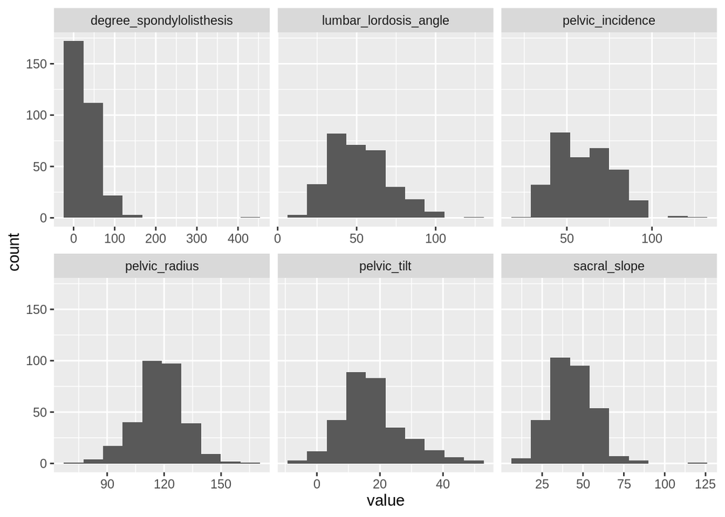

## Goal of the Project

This project has three goals:

1. To construct multiple machine learning models for predicing a patient’s condition.
2. To use these models to build an ensemble model.
3. To investigate whether this ensemble model performs better or worse than the individual models.

## Key steps

The following key steps are performed:

- Pre-process to create test and training sets.
- Construct multiple machine learning models.
- Construct an ensemble model from the models above.
- Final evaluation of ensemble vs. individual models.

# Methods and Analysis

## Pre-Processing

In this section I pre-process the data to create test and training sets (**test_set** and **train_set**, respectively). The training comprises 75% of the full dataset; the test_set comprises the remaining 25 percent.

## Modelling Approach

I build the following machine learning models:

1. Naive Bayes
2. Linear Discriminant Analysis (LDA)
3. K-Nearest Neighbours (KNN)
4. Support Vector Machines (SVMs)
5. Decision Tree
6. Random Forest

For each of these models I train (and optimize where relevent) on the **train_set** and evaluate its accuracy on the **test_set**. Each of these are models are discussed in turn below.

### 1. Naive Bayes

I train the Naive Bayes model below:

```r
## Train Naive Bayes Model
train_nb <- train(class ~ ., method = 'naive_bayes', data = train_set)
## see how accurate this model is
y_hat_nb <- predict(train_nb, test_set, type = "raw")
acc_nb <- mean(y_hat_nb ==test_set$class)
acc_results <- data_frame(method = "Naive Bayes", Accuracy = acc_nb)
```

The Naive Bayes model achieves 0.9102564 accuracy on the **test_set**.

### 2. Linear Discriminant Analysis (LDA)

I train the LDA model below:

```r
## Train LDA
fit_lda <- train(class ~ ., data = train_set, method = 'lda')
y_hat_lda <- predict(fit_lda, test_set)
##Evaluate Accuracy
acc_lda <- mean(y_hat_lda ==test_set$class)
```

The LDA model achieves 0.8846154 accuracy on the **test_set**.

### 3. K-Nearest Nieghbours (KNN)

I train the KNN model below and optimize K on the **train_set** from 2 to 50, as shown in the plot below.

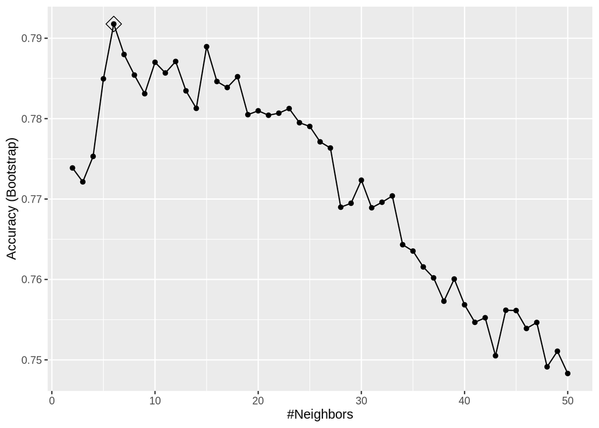

```r
#optize over K on train_set
train_knn <- train(class ~ ., method = "knn", data = train_set,
                   tuneGrid = data.frame(k = seq(2, 50, 1)))
ggplot(train_knn, highlight = TRUE)
```

```r
# get best k
best_k <- train_knn$bestTune$k
y_hat_knn <- predict(train_knn, test_set, type = "raw")
acc_knn <- mean(y_hat_knn == test_set$class)

#get train set accuracy
y_hat_knn_train <- predict(train_knn, train_set, type = "raw")
acc_knn_train <- mean(y_hat_knn_train ==train_set$class)
```

The optimal value for K is 6. This model has accuracy of 0.8333333 on the **test_set**.

### 4. Support Vector Machines (SVM)

I estimate 3 SVM models each with a different kernel: linear, polynomial, radial. I optimse by selecting the kernel with higest accuracy on the **train_set**.

```r
## Instal libray for SVMs
if(!require(e1071)) install.packages("e1071", repos = "http://cran.us.r-project.org")
library(e1071)

# define function for SVM
est_svm <- function(k){
    svm_fit = svm(formula = class ~ .,
                 data = train_set,
                 type = 'C-classification',
                 kernel = k)

    y_hat = predict(svm_fit,train_set)
    mean(y_hat==train_set$class)

}

# estimate SVM for each kernel type
svms<- sapply(kernels, est_svm)

# choose kernel that maximises train_set accuracy
idx <-which.max(svms)
kernel <- kernels[idx]
```

SVM: Training set accuracy for each kernel

|  | x |
| --- | --- |
| linear | 0.8620690 |
| polynomial | 0.8189655 |
| radial | 0.8836207 |

The radial kernel maximises accuracy on the **train_set** and this model has 0.8717949 accuracy on the **test_set**.

### 5. Decision Trees

I train a decision tree on the **train_set** and optimise for the complexity parameter:

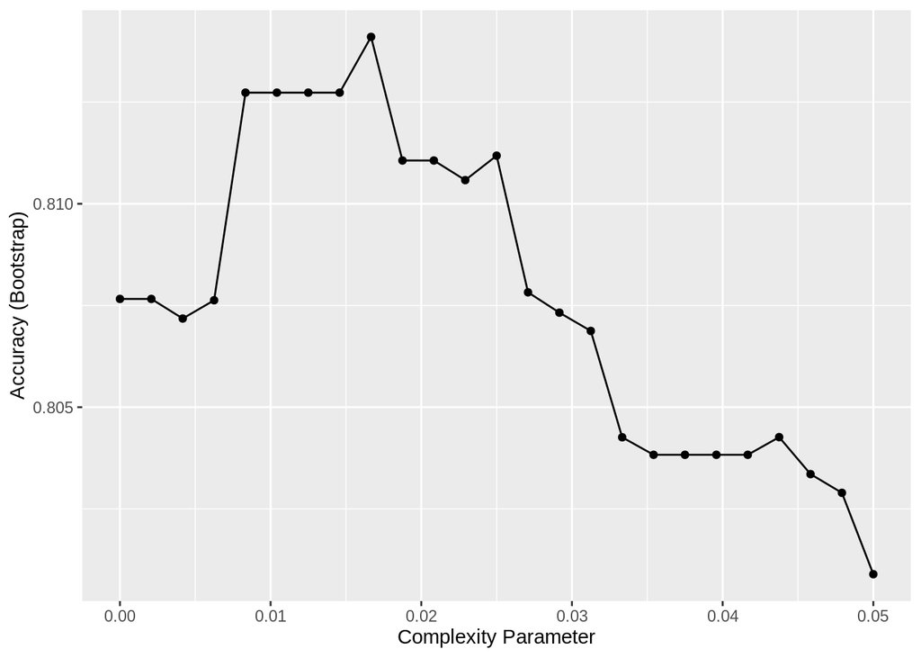

```r
# train and optimize CP on train_set
train_rpart <- train(class ~ .,method = "rpart",
                  tuneGrid = data.frame(cp = seq(0, 0.05, len = 25)),
                  data = train_set)

#select best CP
best_cp <- train_rpart$bestTune$cp
y_hat_dt <- predict(train_rpart, test_set)
acc_dt <- mean(y_hat_dt ==test_set$class)

# get most variable importance
imp_dt <- varImp(train_rpart)

#plot CP selection
ggplot(train_rpart)
```

The best complexity parameter is 0.0166667 and this model has accuracy of 0.8846154 on the **test_set**. The corresponding decision tree and table with feature importance are shown below:

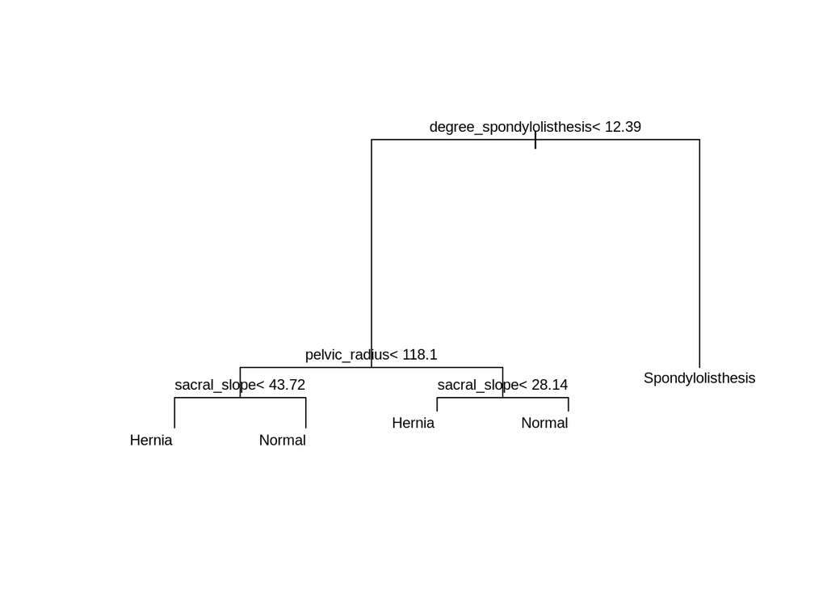

Feature Importance

[output not shown]

### 6. Random Forests

I train random forests and optimise *‘mtry’* over the range 50-300, in increments of 25, on the *train_set*.

```r
## Download libraray
if(!require(randomForest)) install.packages("randomForest", repos = "http://cran.us.r-project.org")
library(randomForest)

## Set seed to ensure reproducability
set.seed(1, sample.kind="Rounding")

## train and optimise RF model
train_rf <- train(class ~., train_set,
              method = "rf",
                nodesize = 1,
              tuneGrid = data.frame(mtry = seq(50, 300, 25)))

# select best mtry parameter
best_m <- train_rf$bestTune$mtry

#predict
y_hat_rf <- predict(train_rf,test_set)
acc_rf <- mean(y_hat_rf == test_set$class)

#feature importance
imp_rf <- varImp(train_rf)
kable(imp_rf$importance, caption ='Feature Importance')
```

Feature Importance

|  | Overall |
| --- | --- |
| pelvic_incidence | 0.0394151 |
| pelvic_tilt | 3.0511046 |
| lumbar_lordosis_angle | 0.0000000 |
| sacral_slope | 10.6753751 |
| pelvic_radius | 10.1759821 |
| degree_spondylolisthesis | 100.0000000 |

The optimal *mtry* value is 75 and this model has 0.8974359 accuracy on the **test_set**.

### Summary of Individual Models

So far we have estimated 6 models with **test_set** accuracy shown in the table below:

Summary of Model Accuracy

| Method | Accuracy |
| --- | --- |
| Naive Bayes | 0.9102564 |
| LDA | 0.8846154 |
| KNN | 0.8333333 |
| SVM | 0.8717949 |
| Decision Tree | 0.8846154 |
| Random Forest | 0.8974359 |

The Naive Bayes is the best model with accuracy of 0.9102564 on the **test_set**.

I will now try and beat this with an ensemble - this will be tough, since accuracy is already very high.

## Ensemble modelling

An ensemble model is a model that combines multiple other models to make the predictions. I create an emsemble model by giving each individual model a ‘vote’ on the correct prediction. That is, for each obervation (ie, row) I take the mode of the indivual models’ predictions. (Note that by chosing the mode there is a chance for two-way or three-way ties, but fortunately for this experiment there are no ties).

Code for constructing the ensemble is shown below:

```r
## Download library for deriving mode and install
if(!require(modeest)) install.packages("modeest", repos = "http://cran.us.r-project.org")
library(modeest)

## collate all predictions
all_y_hat <- c(data.frame(y_hat_nb), data.frame(y_hat_lda),data.frame(y_hat_knn),
               data.frame(y_hat_svm),data.frame(y_hat_rf),data.frame(y_hat_svm),
               data.frame(y_hat_dt))
all_y_hat <- data.frame(all_y_hat)
kable(head(all_y_hat), caption = 'Sample of all models before taking mode')
```

Sample of all models before taking mode

| y_hat_nb | y_hat_lda | y_hat_knn | y_hat_svm | y_hat_rf | y_hat_svm.1 | y_hat_dt |
| --- | --- | --- | --- | --- | --- | --- |
| Spondylolisthesis | Hernia | Hernia | Hernia | Hernia | Hernia | Normal |
| Normal | Normal | Normal | Normal | Normal | Normal | Spondylolisthesis |
| Hernia | Hernia | Normal | Hernia | Hernia | Hernia | Hernia |
| Hernia | Hernia | Hernia | Hernia | Hernia | Hernia | Hernia |
| Hernia | Normal | Normal | Normal | Normal | Normal | Normal |
| Hernia | Hernia | Hernia | Normal | Normal | Normal | Hernia |

The most frequent prediction in row one is ‘Hernia’ and ‘Normal’ for row two. So the ensemble predicts ‘Hernia’ for row one and ‘Normal’ for row two. The code for doing this is shown below:

```r
## get mode
y_hat_final <- apply(all_y_hat[ ,1:length(all_y_hat)], 1, mfv)
y_hat_final <- data.frame(y_hat_final)

## get accuracy of ensemble
acc_en <- mean(y_hat_final == data.frame(test_set$class))
acc_results <- bind_rows(acc_results, data_frame(Method="Ensemble", Accuracy = acc_en ))
```

## Results

All of the model perform well in terms of accuracy of predictions. Full summary shown below:

Model Accuracy - with ensemble

| Method | Accuracy |
| --- | --- |
| Naive Bayes | 0.9102564 |
| LDA | 0.8846154 |
| KNN | 0.8333333 |
| SVM | 0.8717949 |
| Decision Tree | 0.8846154 |
| Random Forest | 0.8974359 |
| Ensemble | 0.9102564 |

The ensemble model has 0.9102564 accuracy on the **test_set**, matching the best individual model (Naive Bayes).

## Conslusion

In this report I demonstrate how to construct an ensemble using multiple models. The final ensemble performed well, but could only match and not exceed the single best individual mdoel.

Another area for future work would be to determine how to break ties if the ensemble had the same number of ‘votes’ for two or three predictions. I considered considered using **train_set** accuracy as a voting weight; hence a model that was more accurate in training would have a greater contribution to the final ‘vote’. Fortunately, for this dataset, tie-breaking was not necessary.

I have only considered accuracy, but perhaps should also consider precision and recall. This is especially relevent in medicine since the cost of a false negative (ie, an undiagnosed condition) could be very high for the patient.